# STAT 687 - Chapter 1

Reliability Concepts and Reliability Data

Maj Jason Freels

Air Force Institute of Technology

# meekR Package

## meekR Package - Background

STAT 687 - Chapter 1

Originaly created as SPLIDA (S-Plus LIfe Data Analysis)

- Developed over Bill Meeker’s career at Bell Labs and ISU
- Companion to the Meeker & Escobar text ‘Statistical Methods for Reliability Data’
- Intended to be used as a gui interface

SPLIDA was later ported to R as “RSplida”

- Port was rushed and incomplete
- Difficult to use
- Couldn’t be used with RStudio

## meekR Package - Background

STAT 687 - Chapter 1

**No RStudio?…uh, no**

```r
load("echapters.RData", envir=globalenv())
load("RSplida Codes.RData", envir=globalenv())
load("RSplidaData.RData", envir=globalenv())
load("RSplidaUser.RData", envir=globalenv())
load("Text data.RData", envir=globalenv())
###<b>
dyn.load("DFORRT.dll",envir=globalenv())
dyn.load("SPLIDA.dll",envir=globalenv())  #30,000 lines of FORTRAN in here
###</b>
```

Signed MOU w/ Bill Meeker to use FORTRAN code to build ‘meekR’ package

## meekR Package - Purpose

STAT 687 - Chapter 1

Compute statistical quantities for data sets with

- Multiple failure modes
- Right, left, and interval censoring
- Right, left, and interval truncation
- Accelerated stresses (normal, Weibull, and logistic regression)
- Repeated measures
- Recurring events (Current: HPP & NHPP Future: SMP)
- Physical degradation
- Prior information (Bayesian Reliability)
- Reliability growth

Also, can simulate reliability tests

## meekR - Completely reformatted for R

STAT 687 - Chapter 1

**RSplida**

- Retains many of the ‘gui’ limitations of SPLIDA
- Can’t be used with RStudio
- Results print to the screen - not usable for dynamic reports/presentations
- Not user-friendly

**meekR**

- Seamless workflow - create papers/presentations incredibly fast
- High-quality plots
- Turn results into $\LaTeX$ tables instantly {xtable, stargazer, pander}
- Easily create interactive content {shiny, htmlwidgets, ggvis}

## Over 120 data sets built into the package

STAT 687 - Chapter 1

```r
meekR.data[1:24]
```

```
>  [1] "adhesivebondc"        "adhesivestrength"     "alloya"
>  [4] "alloyc"               "amsaaexactfail"       "amsaawindow1"
>  [7] "amsaawindow2"         "appliancea"           "applianceb"
> [10] "aprel72"              "at7987"               "atrazinejune"
> [13] "audioquality"         "bearinga"             "bearingcage"
> [16] "berkson10220"         "berkson20"            "berkson200"
> [19] "berkson2000"          "bkfatigue10"          "bleed"
> [22] "bulb"                 "censortruncationtest" "ceramicbearing"
```

```r
length(meekR.data)
```

```
> [1] 123
```

## This chapter explains

STAT 687 - Chapter 1

[interactive chart not shown]

- Basic ideas behind product reliability
- Reasons for collecting reliability data
- Distinguishing features of reliability data
- General models for reliability data
- Examples of reliability data and motivations for collecting the data
- A general strategy used for data analysis, modeling, and inference from reliability data

# Section 1.1|Introduction

## $\S$ 1.1.1 - Quality and Reliability

STAT 687 - Chapter 1

*RELIABILITY* - A **stochastic** measure of the likelihood that a component or system will perform its **required function(s)** for a specified **period of operation** under stated **operating conditions**

- **Stochastic** - True value is random and uncertain
- **Required function** - must be specifically defined
- **Period of operation** - may be continuous or discrete
  - Continuous - time, distance
  - Discrete - shots, launches, take-off/landing cycles
- **Operating conditions** - must be defined

## Why Study Reliability?

STAT 687 - Chapter 1

- Ever-increasing system complexity and sophistication
- Public awareness and insistence on product reliability
- Profit considerations resulting from the high cost of failures, repairs, and warranty programs
- Government contractual requirements to meet reliability and maintainability performance specifications
- Laws and regulations concerning product liability and safety

## The Reliability Environment

STAT 687 - Chapter 1

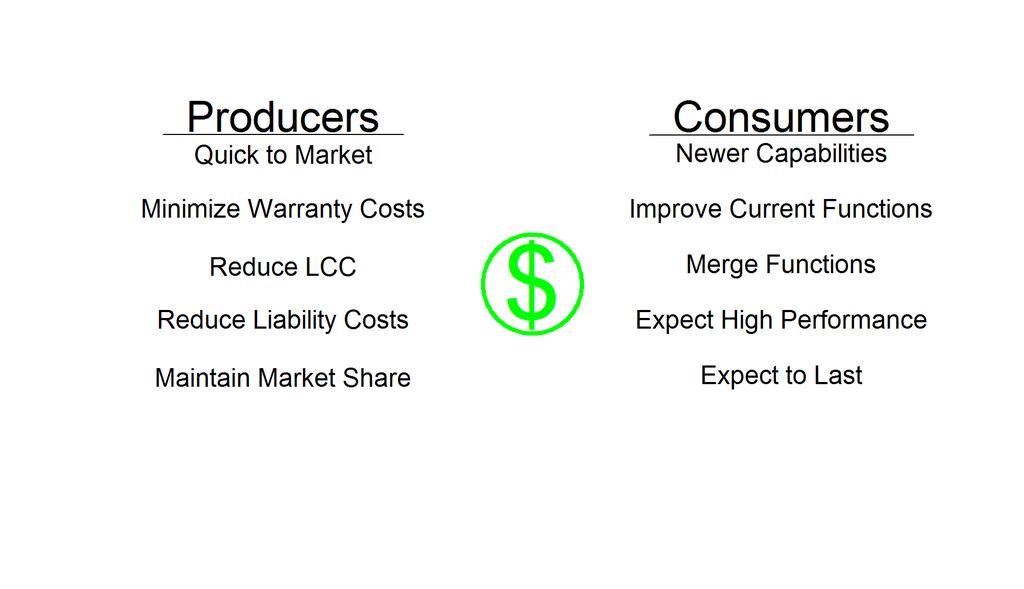

## The Reliability Environment

STAT 687 - Chapter 1

```r
par(bg=NA)
plot(NA, xlim=range(0,500),ylim=range(0,500), axes = FALSE, xlab = "", ylab = "")

text(c(100,250,400),c(475,250,475),
     c(expression(underline("  Producers  ")),
       "$",
       expression(underline("  Consumers  "))),
     cex = c(2.5,6,2.5), font = 2, col = c(1,"green",1))

text(rep(100,5),seq(425,75,-75), c("Quick to Market",
                                  "Minimize Warranty Costs",
                                  "Reduce LCC",
                                  "Reduce Liability Costs",
                                  "Maintain Market Share"),  cex = rep(1.5,5))

text(rep(400,5),seq(425,75,-75), c("Newer Capabilities",
                                   "Improve Current Functions",
                                   "Merge Functions",
                                   "Expect High Performance",
                                   "Expect to Last"), cex = rep(1.5,5))
points(250, 250, col = "green", cex = 13, lwd = 4)
```

## Inputs to the Reliability Environment

STAT 687 - Chapter 1

Many internal and external actors effect the reliability environment

**Engineers/Scientists**

- New materials
- New system architectures

**Government**

- New safety requiments (for consumers and employees)
- New environmental regulations

## Inputs to the Reliability Environment

STAT 687 - Chapter 1

**Competitors**

- Newer (and possibly improved) products
- Reduce profit margins
- Increase cost of raw materials
- Reduced time to market

**Testing**

- New capabilities to stress products
- New techniques to evaluate data

## $\S$ 1.1.2 - Reasons for Collecting Reliability Data

STAT 687 - Chapter 1

- Assess performance characteristics of materials over design life
- Predict product reliability
- Assess the effect of a proposed design change
- Compare components from different manufacturers
- Assess product reliability in field
- Checking the veracity of an advertising claim
- Track new failure modes
- Predict product warranty costs
- Ensure safety requirements are met

## Distinguishing Features of Reliability Data

STAT 687 - Chapter 1

Data are typically **censored**

Positive responses (e.g., time or cycles to failure) are modeled

- Common distributions: exponential, lognormal, Weibull, gamma
- Normal distribution is not common

Model parameters not of primary interest (instead, failure rates, quantiles, probabilities)

Extrapolation often required

Data structures can be very complex (closed form solutions rarely exist)

Software required to solve all but most basic problems (this class will use R)

# Section 1.2|Reliability Data Examples

## $\S$ 1.2.1 - Failure data (no explanatory variables)

STAT 687 - Chapter 1

Modeling time-to-event data can produce poor results if

- The time-scale used to measure life differs between test units
- The severity of the test environment is not considered

Explanatory variables are used to define the severity of a test environment (how quickly “life” is consumed)

If the test severity is equivalent across each test unit, the observations are assumed to be $iid$ and expanatory variables may be ignored

Assuming $x_{i} \sim iid, \forall i$ implies that any differences in the sample population or test process are captured by $Var[X]$

## Example 1.1 - Ball bearing fatigue test

STAT 687 - Chapter 1

**Motivation for the study**

- Fatigue affects service life of ball bearings
- Disagreement in the industry on the appropriate parameter values to use

**Objectives of the study**

- Determine best parameter values in equation relating fatigue to load in deep-groove ball bearings

**Data set** (Table 1.1)

- “Exact” number of revolutions (in Millions) recorded for each of $n = 23$ bearings before fatigue failure

## Example 1.1 - Ball bearing fatigue failure data

STAT 687 - Chapter 1

```r
as.list(lzbearing)
```

```
## $Megacycles
##  [1]  17.88  28.92  33.00  41.52  42.12  45.60  48.40  51.84  51.96  54.12
## [11]  55.56  67.80  68.64  68.64  68.88  84.12  93.12  98.64 105.12 105.84
## [21] 127.92 128.04 173.40
```

## Figure 1.1 - Histogram of ball bearing failure data

STAT 687 - Chapter 1

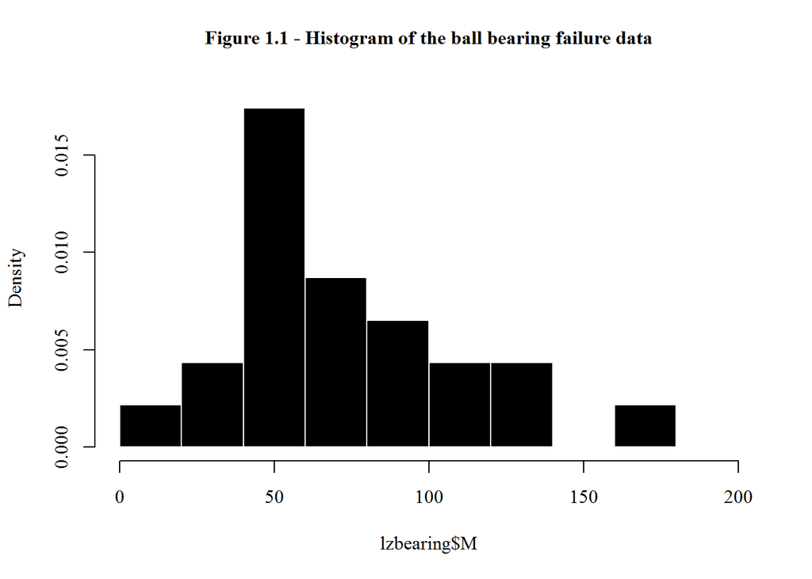

```r
par(family="serif",font=2,bg=NA)
hist(lzbearing$M,breaks=seq(0,200,20),col="black",border="white",prob=TRUE,main="")
mtext(side = 3,"Figure 1.1 - Histogram of the ball bearing failure data",line = 2)
```

## Example 1.2 - Integrated circuit life test

STAT 687 - Chapter 1

**Motivation for the study**

- Temperature & humidity affects service life of IC’s

**Objectives of the study**

- Determine probability of IC’s failing before 100 hours
- Determine hazard function at 100 hours
- Determine proportion of units that will fail in 105 hours

**Data set** (Table 1.2)

- $n = 4156$ IC’s tested for 1370 hours at $80^{o}C$ and $80\%$ relative humidity, there were 28 failures (Meeker 1987).

## Figure 1.2 - IC life test data

STAT 687 - Chapter 1

```r
head(lfp1370)
```

```
##   Hours  Status Weight
## 1  0.10 Failure      2
## 2  0.15 Failure      1
## 3  0.60 Failure      1
## 4  0.80 Failure      2
## 5  1.20 Failure      1
## 6  2.50 Failure      1
```

```r
tail(lfp1370)
```

```
##    Hours   Status Weight
## 17    84  Failure      1
## 18    94  Failure      1
## 19   168  Failure      1
## 20   263  Failure      1
## 21   593  Failure      1
## 22  1370 Censored   4128
```

## Figure 1.3 - Event plot for IC life test data

STAT 687 - Chapter 1

- The `event.plot` command is part of the meekR package
- meekR commands can only be performed on **life.data** objects
- `frame` refers to the data set formatted as a **data.frame**
- `frame.to.ld` converts **data.frame** into an **life.data** object

```r
IC.ld<-frame.to.ld(frame = lfp1370, response.column = 1,
                   censor.column = 2,
                   case.weight.column = 3,
                   data.title = "IC Failure Data",
                   time.units = "Hours")
```

## Figure 1.3 - Event plot for IC life test data

STAT 687 - Chapter 1

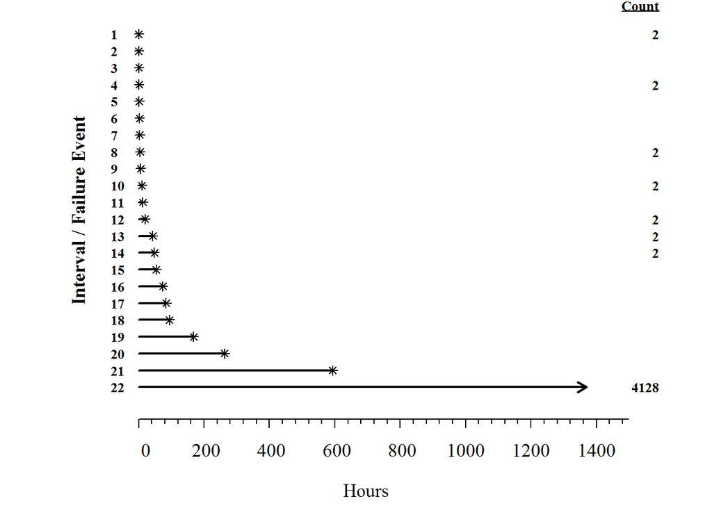

```r
event.plot(IC.ld)
```

## Example 1.5 - Heat Exchanger Tube Crack Data

STAT 687 - Chapter 1

**Motivation for the study**

**Objectives of the study**

**Data set** (Table 1.2)

## Fig 1.6 - Heat exchanger crack inspection data

STAT 687 - Chapter 1

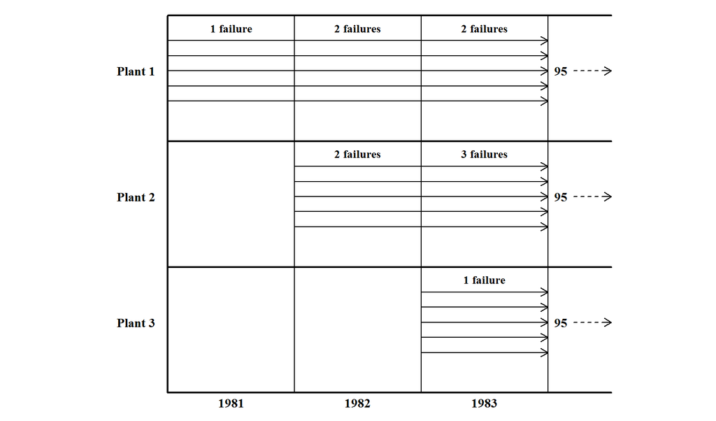

## Fig 1.6 - Heat exchanger crack inspection data

STAT 687 - Chapter 1

```r
plot(NA,axes=FALSE,xlab="",ylab="",xlim=range(-50,350),ylim=range(-10,300))
segments( c(0,0,0,0,0,rep(0,5),rep(100,5),rep(200,5),100,200,300),
          c(0,100,200,300,0,seq(232,280,12),seq(132,180,12),seq(32,80,12),0,0,0),
          c(350,350,350,350,0,rep(300,15),100,200,300),
          c(0,100,200,300,300,seq(232,280,12),seq(132,180,12),seq(32,80,12),300,300,300),
            lwd=c(rep(2,5),rep(1,18)))
text(rep(-25,3),seq(56,256,100),c("Plant 3","Plant 2","Plant 1"),cex=rep(0.9,3))
text(c(50,rep(150,2),rep(250,3)),c(rep(290,2),190,290,190,90),
     c("1 failure","2 failures","2 failures","2 failures","3 failures","1 failure"),
     cex=rep(0.8,6))
text(seq(50,250,100),rep(-8,3),c("1981","1982","1983"),cex=rep(0.9,3))
text(rep(310,3),seq(56,256,100),rep("95",3),cex=rep(0.9,3))
segments(rep(320,3),seq(56,256,100),rep(345,3),seq(56,256,100),lty=rep(2,3))
arrows(rep(295,15),c(seq(232,280,12),seq(132,180,12),seq(32,80,12)),rep(300,15),length=rep(0.1,15))
arrows(rep(345,3),seq(56,256,100),rep(350,3),length=rep(0.1,3))
```

## Fig 1.7 - Heat exchanger crack inspection data

STAT 687 - Chapter 1

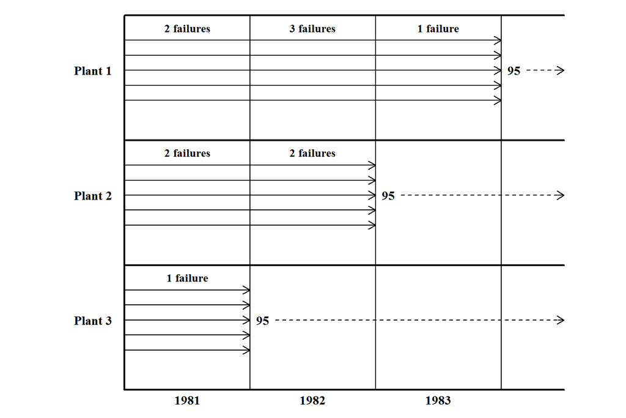

## Fig 1.7 - Heat exchanger crack inspection data

STAT 687 - Chapter 1

```r
par(family="serif",font=2,bg=NA)
plot(NA,axes=FALSE,xlab="",ylab="",xlim=range(-50,350),ylim=range(-10,300))
segments( c(0,0,0,0,0,rep(0,15),100,200,300),
          c(0,100,200,300,0,seq(232,280,12),seq(132,180,12),seq(32,80,12),0,0,0),
          c(350,350,350,350,0,rep(300,5),rep(200,5),rep(100,5),100,200,300),
          c(0,100,200,300,300,seq(232,280,12),seq(132,180,12),seq(32,80,12),300,300,300),
            lwd=c(rep(2,5),rep(1,18)))
text(rep(-25,3),seq(56,256,100),c("Plant 3","Plant 2","Plant 1"),cex=rep(0.9,3))
text(c(rep(50,3),rep(150,2),250),c(90,190,290,190,rep(290,2)),
     c("1 failure","2 failures","2 failures","2 failures","3 failures","1 failure"),
     cex=rep(0.8,6))
text(seq(50,250,100),rep(-8,3),c("1981","1982","1983"),cex=rep(0.9,3))
text(c(110,210,310),seq(56,256,100),rep("95",3),cex=rep(0.9,3))
segments(c(120,220,320),seq(56,256,100),c(345,345,345),seq(56,256,100),lty=rep(2,3))
arrows(c(rep(295,5),rep(195,5),rep(95,5)),
       c(seq(232,280,12),seq(132,180,12),seq(32,80,12)),
       c(rep(300,5),rep(200,5),rep(100,5)),length=rep(0.1,15))
arrows(rep(345,3),seq(56,256,100),rep(350,3),length=rep(0.1,3))
```

## $\S$ 1.2.2 - Failure data (w/ explanatory variables)

STAT 687 - Chapter 1

- When units are tested at multiple environments with differing levels of severity:
  - Explanatory variables can be used to relate how quickly “life” is consumed in each environment
  - Changing the value of the explanatory variables changes the parameter values in the underlying failure distribution (think regression)
  - Complex models are often required to compare life consumption rates between severity levels
- Life can be measured as
  - Crack length in a structural member
  - Material loss in a wear test or corrosive environment

## Example 1.8 - Printed circuit board ALT data

STAT 687 - Chapter 1

**Motivation for the study**

- Relative humidity $\%RH$ affects time to short-circuit in PCB’s
- Failures may be generated more quickly by increasing $\%RH$

**Objectives of the study**

- Determine the proportion of PCB’s failing at the “use” humidity

**Data set** (Table 1.2)

- $n = 70$ PCB’s tested at each of $4$ levels of $\%RH$
- Time until short-circuit assessed in $4$- or $12$-hour intervals

## Figure 1.9 - Scatterplot of PCB ALT data

STAT 687 - Chapter 1

```r
head(printedcircuitboard)
```

```
##   HoursL HoursU Weight Status   RH
## 1     14     18      1      4 82.4
## 2     18     22      1      4 82.4
## 3     30     34      8      4 82.4
## 4     42     46      3      4 82.4
## 5     46     50      3      4 82.4
## 6     50     54      3      4 82.4
```

```r
tail(printedcircuitboard)
```

```
##     HoursL HoursU Weight Status   RH
## 135   2353   2365      1      4 49.5
## 136   2450   2462      1      4 49.5
## 137   2498   2510      1      4 49.5
## 138   3170   3182      1      4 49.5
## 139   3914   3926      1      4 49.5
## 140   4078   4078     48      2 49.5
```

## Figure 1.9 - Scatterplot of PCB ALT data

STAT 687 - Chapter 1

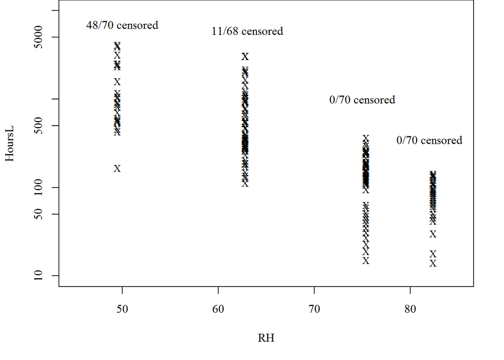

```r
par(family="serif", font=1, bg=NA, mar = c(5.1, 4.1, 0, 2.1))
plot(HoursL~RH, data=printedcircuitboard, pch="X", cex=.85,log="y", ylim=c(10,10000),xlim=c(45,85))
text(c(50,63,75,82),c(7000,6000,1000,350),
     c("48/70 censored","11/68 censored","0/70 censored","0/70 censored"))
```

## $\S$ 1.2.3 - Degradation data (no explan. variables)

STAT 687 - Chapter 1

Degradation occurs as some physical measurement approaches a critical value

Degradation failures can be defined as **soft** or **hard**

- **Soft failure:** - System performance falls below an acceptable level
  - Power windows raise/lower too slowly
  - Tire tread depth
- **Hard failure:** - System stops working/breaks
  - Power window motor or switch fails
  - Tire fails

So why doesn’t [**this**](http://www.centennialbulb.org) degrade?

# Section 1.3|General Models for Reliability Data

## $\S$ 1.3.1 - Define target population or process

STAT 687 - Chapter 1

Most statistics courses discuss **Enumerative Studies**

- Test a random sample from a population of units
- Observe test results, analyze data, and make conclusions

BUT, what if your conclusion is…  
**these parts suck and come nowhere close to meeting the requirement?**

- You improve the design, and now…
- Your test data is based on a prior design that doesn’t exist anymore

Enumerative studies are used to assess the performance of MATURE products

## $\S$ 1.3.1 - Define target population or process

STAT 687 - Chapter 1

Many reliability tests are **Analytic Studies**

## $\S$ 1.3.2 - Degradation leads to failure

STAT 687 - Chapter 1

Failure results when a manufacturing flaw or design weakness is exposed to a severe environment for a sufficient period of time.

The environment imparts stresses within the system which over time can

- Extend microcracks
- Loosen joints
- Weaken electical connections
- Magnify vibrations
- Elevate temperature

These strains weaken the system until the environmental stresses exceed the flaw’s residual strength

## $\S$ 1.3.2 - Degradation leads to failure

STAT 687 - Chapter 1

[interactive chart not shown]

## $\S$ 1.3.2 - Degradation leads to failure

STAT 687 - Chapter 1

[interactive chart not shown]

```r
inputPanel(
  sliderInput("mean", label = "Applied Stress:",
              min = 5, max = 16, value = 5, step = 1, animate=TRUE)
)

renderPlot({
  par(family="serif",bg=NA)
  plot(seq(0,30,.1),dnorm(seq(0,30,.1),input$mean,2),xlim=range(0,22),ylim=range(0,.2),ylab="", xlab="Stress",type="l",lwd=2,col="blue")
  segments(17,0,17,.3,col="red",lwd=4)
  polygon(c(17,seq(17,22,.1),22),c(0,dnorm(seq(17,22,.1),input$mean,2),0),col=rgb(1,0,0,.25),border=NA)
  text(18.5,.19,"Stress Limit",font=2,cex=1.5)
})
```

## $\S$ 1.3.3 - Environmental effects of reliability

STAT 687 - Chapter 1

It’s understood that system performance is affected by the operating environment

It’s less understood how many different environments a system is exposed to

[video not shown]

## $\S$ 1.3.4 - Definition of time-scale

STAT 687 - Chapter 1

The lifetime of most systems can be quantified using multiple “time-scales”

**Example: Convection oven**

- Timescale 1: Years of ownership
- Timescale 2: Thermal cycles
- Timescale 3: Total energy consumed

Each customer may have their own time-scale of interest

Each system component has a time-scale that is most appropriate

## $\S$ 1.3.5 - Defining time origin and failure time

STAT 687 - Chapter 1

From a producer’s perspective defining when a product life begins can be tricky

- When it leaves the assembly line?
- When it ships from factory to a retailer?
- When it is purchased by a customer?
- When it is installed/unboxed?
- When it is first used?

Is it possible to know when each of these events occur?

## $\S$ 1.3.5 - Defining time origin and failure time

STAT 687 - Chapter 1

Likewise, defining when product life ends can be difficult

- When the customer realizes it has stopped functioning?
- When a warranty claim is made?
- When it is received by the manufacturer?

As this is a statistics course, defining when to start and stop counting product lifetime is not a concern

Recognize these issues must be considered in a consistent manner when collecting time-to-event data

**As part of the class project you will collect your own data!**

# Section 1.4|Repairable Systems and Nonrepairable Units

## $\S$ 1.4.1 - Reliability data (non-repairable units)

STAT 687 - Chapter 1

Non-repairable systems are designed to be replaced rather than repaired

**Not safety critical/inexpensive:** Replace after failure

- Light bulbs
- Small appliances
- Stuff

**Satefy critical/expensive:** Replace at certain degradation level

- Tires (tread depth)
- Computers (processing speed)
- Stuff

## $\S$ 1.4.1 - Reliability data (non-repairable units)

STAT 687 - Chapter 1

Graphically, non-repairable systems may be represented by a two-state transition diagram with an absorbing state

- State 0: Initial working state
- State 1: Absorbing failed state

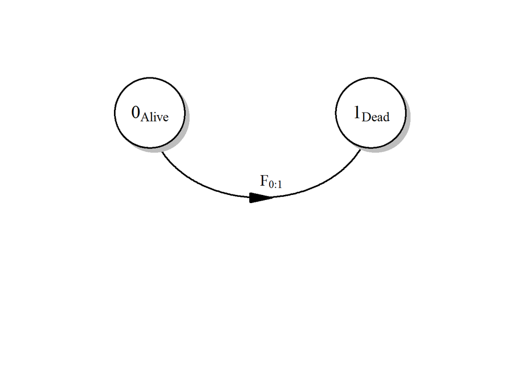

## $\S$ 1.4.2 - Reliability data (repairable systems)

STAT 687 - Chapter 1

Systems for which cost considerations justify repair rather than replacement

Graphically represented by two or more transient states

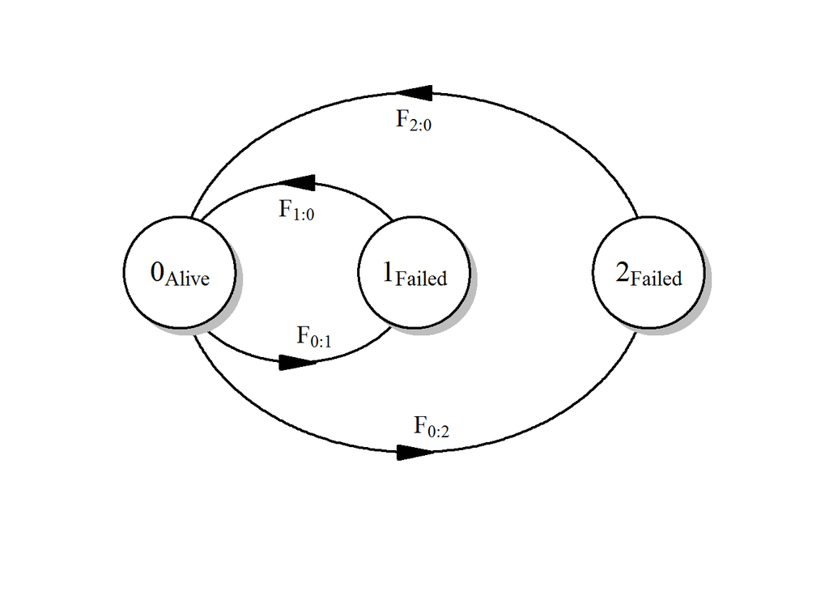

## Repairable vs. non-repairable systems

STAT 687 - Chapter 1

In truth, most systems are repairable AND non-repariable

Or stated more correctly, most systems have both repairable and non-repairable **failure modes**

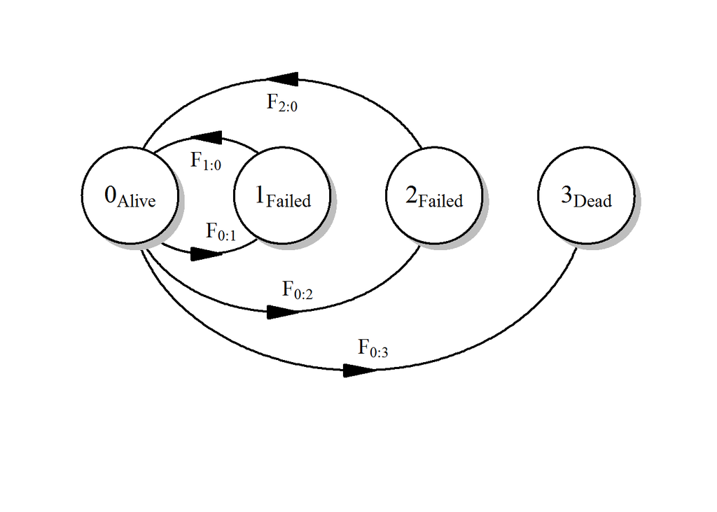

## $\S$ 1.4.2 - Reliability data (repairable systems)

STAT 687 - Chapter 1

```r
library(diagram)

DiffMat <- matrix(NA, nrow = 4, ncol = 4)

AA <- as.data.frame(DiffMat)
AA[[1,2]] <- "F[1:0]"
AA[[1,3]] <- "F[2:0]"
AA[[2,1]] <- "F[0:1]"
AA[[3,1]] <- "F[0:2]"
AA[[4,1]] <- "F[0:3]"

name <- c(expression(0[Alive]), expression(1[Failed]),
          expression(2[Failed]), expression(3[Dead]))

par(family="serif",bg=NA,pin=c(6,4))

diagram::plotmat(A = AA, pos = 4, curve = .575, name = name, lwd = 2,
        arr.len = 0.6, arr.width = 0.25, my = .15,
        box.size = 0.08, arr.type = "triangle", dtext = -1,
        relsize=.99,box.cex=1.5,cex=1.25)
```

# Section 1.5|Strategy for Data Collection, Modeling and Analysis

## $\S$ 1.5.1 - Planning a reliability study

STAT 687 - Chapter 1

**Clearly define the problem to be solved**

- Reliability test campaigns are often composed of many disparate tests
- Each test will have its own goals
- The type(s) of test used depend on where the system is in its development
- The goal of a particular test may not sync with the goal of the test campaign

**Developmental Testing (DT)**  
Improves the performance of immature systems by finding & removing previously undiscovered failure modes

**Operational Testing (OT)**  
Assesses the performance of mature systems in the operational environment against a requirement

## $\S$ 1.5.1 - Planning a reliability study

STAT 687 - Chapter 1

**Clearly define the resouces available (test equip, ranges, personnel, time)**

In **Developmental Test**

- Environmental test chambers
- Performance diagnostic equipment
- Data acquisition systems
- Personnel - technical SME’s for root cause analyses

In **Operational Test**

- Test ranges
- Maintenance equipment
- Personnel - operational SME’s for realistic performance exercises

## $\S$ 1.5.1 - Planning a reliability study

STAT 687 - Chapter 1

**Understand the environment in which the system will operate**

Systems will be stressed in multiple dimensions

How much should be invested to dampen vibrations if thermal loads are most significant?

## $\S$ 1.5.1 - Planning a reliability study

STAT 687 - Chapter 1

**Understand the structure of the data to be gathered**

What metric(s) will be used to validate performance?

**MTBF**  
Mean time between failures

**MTBM**  
Mean time between maintenance (any maintenance?)

**MTBCF**  
Mean time between critical failure (have critical failures been defined?)

**MMH/OH**  
Maintenance-man hours per operational hour

Are the data being gathered support this?

## $\S$ 1.5.1 - Planning a reliability study

STAT 687 - Chapter 1

**Clearly define how precise the results should be (sample size)**

Often, data from **DT** cannot be used to improve the estimates in **OT**

This is a very active research area

## $\S$ 1.5.2 - Study for data analysis and modeling

STAT 687 - Chapter 1

1. Assess the data nonparametrically - using simple graphical methods
2. Fit one or more simple parametric models to the data
3. Check for violations of model assumptions
4. Compute model parameter estimates and confidence intervals
5. Use numeric and graphical methods to check fit to data
6. Perform sensitivity analyses on parameter values and model assumptions

This process will be used throughout the remainder of the course